# *Breast Cancer Predictor Using Clinical and Anthropometric Data.*

## Summary

- Given the clinical and anthropometric data of a new patient, we attempt to predict the presence or absence of breast cancer. These predictions assist the medical staff in taking an appropirate course of action with respect to treatment.
- We chose `Recall` as our metric as minimizing `False Negatives` was our priority (i.e we care more about accurately predicting the presence of breast cancer)
- Our best classifier for chosen metric, Logistic Regression, has given us a recall of `0.7142`
- Meaning only `71.42%` of cases that had breast cancer were predicted by our model and in `28.58%` it incorrectly predicts that a patient does not have breast cancer.
- To achieve better results in future, we recommend using recursive feature elimination and using more data for training.

## Data

The dataset used in this project consists of anthropometric data and parameters gathered in a standard blood analysis. This dataset was created by Miguel Patrício, José Pereira, Joana Crisóstomo, Paulo Matafome, Raquel Seiça, Francisco Caramelo, all from the Faculty of Medicine of the University of Coimbra and also Manuel Gomes from the University Hospital Centre of Coimbra (Patrício et al., 2018). The dataset was sourced from the UCI Machine Learning Repository (Dua and Graff 2017) and it can be found [here](https://archive.ics.uci.edu/ml/datasets/Breast+Cancer+Coimbra), particularly [this file](https://archive.ics.uci.edu/ml/machine-learning-databases/00451/dataR2.csv). Each row in this dataset represents a set of observations of individual patients and each column represents a variable. In this dataset, there are 116 observations and 9 features which are all numerical. There are zero observations with missing values for each class in the dataset. The target column is a binary dependent variable, which indicates the presence (Classification = 2) or absence (Classification = 1) of breast cancer.  
As there are no missing values and data only has numerical features, the only feature transformation used was `Scaling`.

## Analysis and Results

#### Class distributions of some important features

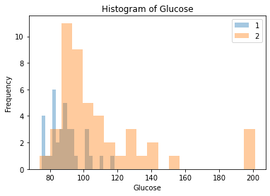

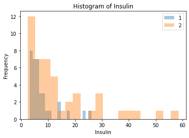

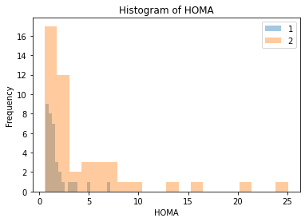

- In the inital analysis it seems like Glucose, Insulin and HOMA are able to differentiate the classes presence of breast cancer and absence of breast cancer

### Cross validation results for different classifiers

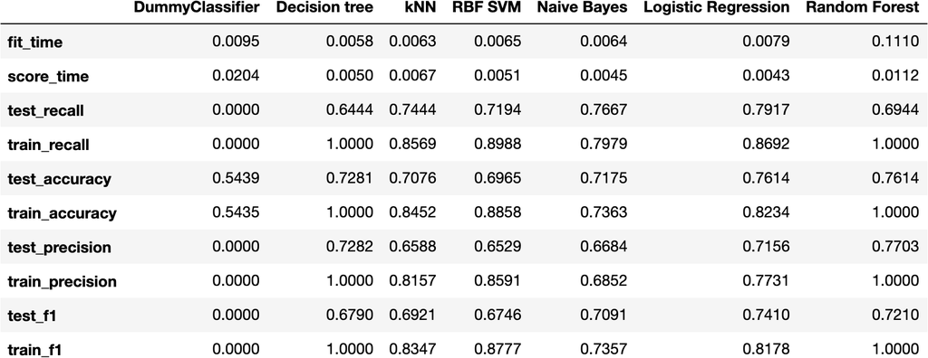

- DummyClassifier was used as baseline model.
- All scaled numeric features were used to fit Decision tree, kNN, RBF SVM, Naive Bayes, Logistic Regression, Random Forest classifiers.
- Decision tree classifier and Random Forest classifer have high train scores for accuracy but much lower validation scores, which indicates overfitting on the training data. Hence, we eliminate these classifiers.
- When compared to all other classifiers, it turned out that `Logistic Regression` has achieved highest validation recall performance with hyperparamter `C` = 100 and hence it was chosen for this prediction task.
- **We have achieved 0.625 accuracy and 0.714 recall.**
- The code used to perform the analysis and create this report can be found here: https://github.com/UBC-MDS/dsci522-group16.

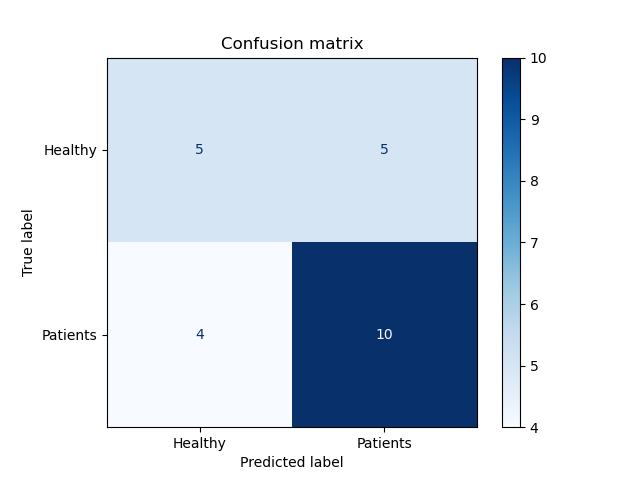

- From confusion matrix we observe that `Accuracy` and `Recall` could be improved

# *References*

Patrício, M., Pereira, J., Crisóstomo, J., Matafome, P., Gomes, M., Seiça, R. and Caramelo, F., 2018. Using Resistin, glucose, age and BMI to predict the presence of breast cancer. BMC Cancer, 18(1). https://doi.org/10.1186/s12885-017-3877-1

Dua, Dheeru, and Casey Graff. 2017. “UCI Machine Learning Repository.” University of California, Irvine, School of Information; Computer Sciences. http://archive.ics.uci.edu/ml.

de Jonge, E., 2020. CRAN - Package Docopt. [online] Cran.r-project.org. Available at: https://cran.r-project.org/web/packages/docopt/index.html [Accessed 29 November 2020].

Oliphant, T.E., 2006. A guide to NumPy, Trelgol Publishing USA.

McKinney, W. & others, 2010. Data structures for statistical computing in python. In Proceedings of the 9th Python in Science Conference. pp. 51–56.

Waskom, M. et al., 2017. mwaskom/seaborn: v0.8.1 (September 2017), Zenodo. Available at: https://doi.org/10.5281/zenodo.883859.

Van Rossum, G. & Drake, F.L., 2009. Python 3 Reference Manual, Scotts Valley, CA: CreateSpace.

Hunter, J.D., 2007. Matplotlib: A 2D graphics environment. Computing in science & engineering, 9(3), pp.90–95.

Pedregosa, F. et al., 2011. Scikit-learn: Machine learning in Python. Journal of machine learning research, 12(Oct), pp.2825–2830.

P'erez, Fernando & Granger, B.E., 2007. IPython: a system for interactive scientific computing. Computing in Science & Engineering, 9(3).

Kluyver, T. et al., 2016. Jupyter Notebooks – a publishing format for reproducible computational workflows. In F. Loizides & B. Schmidt, eds. Positioning and Power in Academic Publishing: Players, Agents and Agendas. pp. 87–90.

Anon, 2020. Anaconda Software Distribution, Anaconda Inc. Available at: https://docs.anaconda.com/.

Ronacher, A., 2020. Jinja. [online] Pallets. Available at: https://palletsprojects.com/p/jinja/ [Accessed 29 November 2020].